```r
load("~/Metrics/Lab5/Lab5/acs2017_ny_data.RData")
```

```r
attach(acs2017_ny)
use_varb <- (AGE >= 25) & (AGE <= 55) & (LABFORCE == 2) & (WKSWORK2 > 4) & (UHRSWORK >= 35) & (Hispanic == 1) & (female == 1) & ((educ_college == 1) | (educ_advdeg == 1))
dat_use <- subset(acs2017_ny,use_varb) #
detach()
```

```r
LinearAge = lm(acs2017_ny$INCWAGE ~ acs2017_ny$AGE + I(acs2017_ny$AGE^2) + I(acs2017_ny$AGE^3) + I(acs2017_ny$AGE^4))
summary(LinearAge)
```

```
##
## Call:
## lm(formula = acs2017_ny$INCWAGE ~ acs2017_ny$AGE + I(acs2017_ny$AGE^2) +
##     I(acs2017_ny$AGE^3) + I(acs2017_ny$AGE^4))
##
## Residuals:
##    Min     1Q Median     3Q    Max
## -57574 -29107  -9101   5946 641975
##
## Coefficients:
##                       Estimate Std. Error t value Pr(>|t|)
## (Intercept)         -6.919e+04  4.829e+03 -14.326  < 2e-16 ***
## acs2017_ny$AGE       3.405e+03  4.560e+02   7.468 8.19e-14 ***
## I(acs2017_ny$AGE^2)  7.387e+01  1.468e+01   5.031 4.88e-07 ***
## I(acs2017_ny$AGE^3) -2.717e+00  1.944e-01 -13.974  < 2e-16 ***
## I(acs2017_ny$AGE^4)  1.744e-02  9.053e-04  19.268  < 2e-16 ***
## ---
## Signif. codes:  0 '***' 0.001 '**' 0.01 '*' 0.05 '.' 0.1 ' ' 1
##
## Residual standard error: 63130 on 163153 degrees of freedom
##   (33427 observations deleted due to missingness)
## Multiple R-squared:  0.08967,    Adjusted R-squared:  0.08965
## F-statistic:  4018 on 4 and 163153 DF,  p-value: < 2.2e-16
```

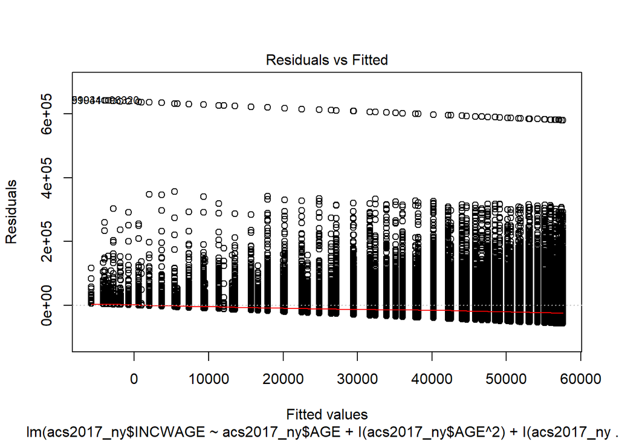

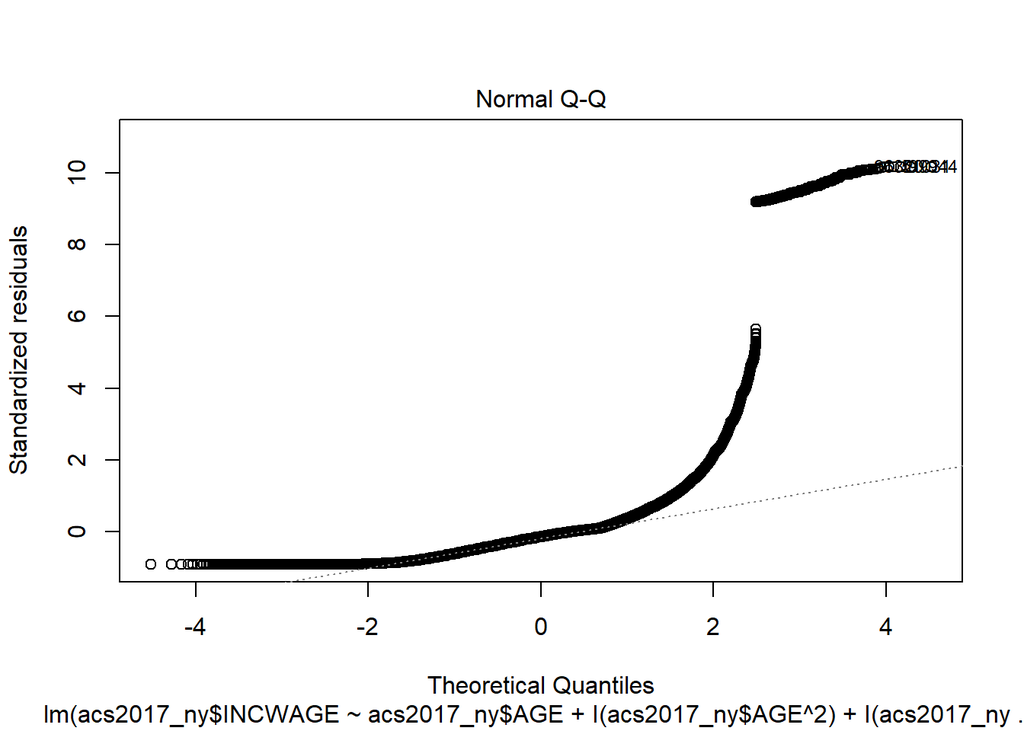

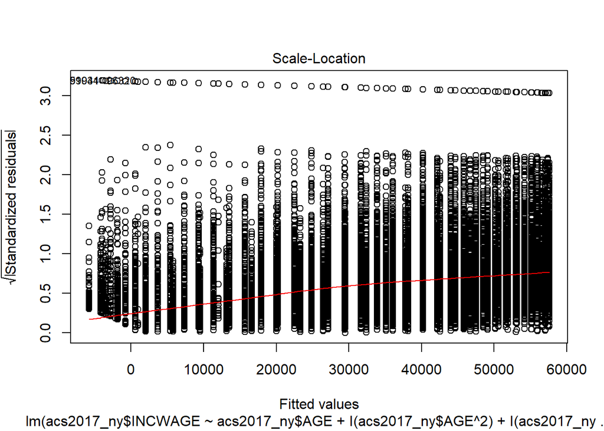

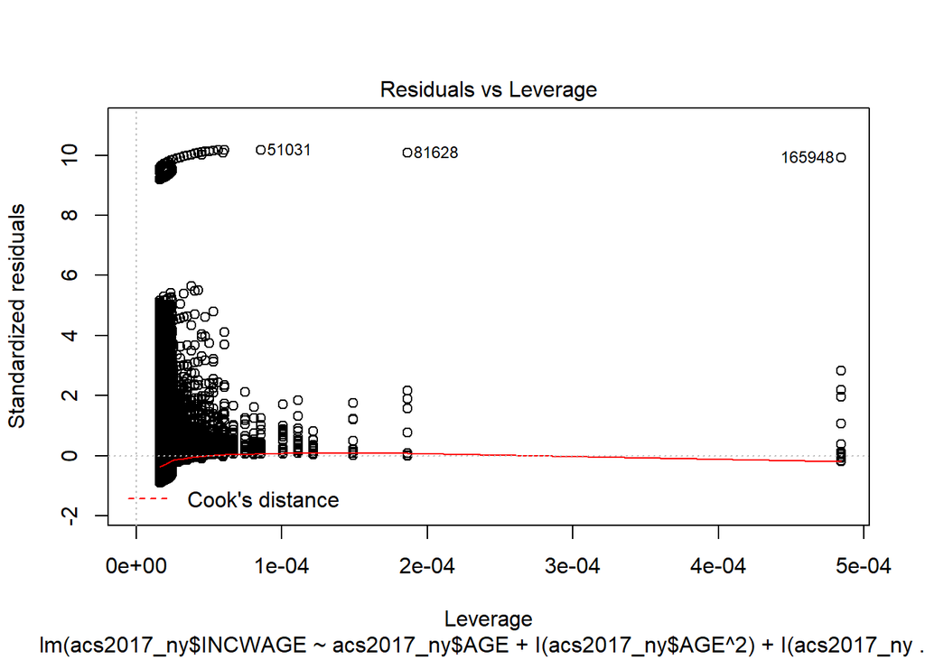

```r
plot(LinearAge)
```

```r
LinearAge2 = lm(acs2017_ny$INCWAGE ~ I(acs2017_ny$AGE^3) + I(acs2017_ny$AGE^4))
summary(LinearAge2)
```

```
##
## Call:
## lm(formula = acs2017_ny$INCWAGE ~ I(acs2017_ny$AGE^3) + I(acs2017_ny$AGE^4))
##
## Residuals:
##    Min     1Q Median     3Q    Max
## -41375 -32848 -18037  12032 686692
##
## Coefficients:
##                       Estimate Std. Error t value Pr(>|t|)
## (Intercept)          3.127e+04  3.136e+02   99.71   <2e-16 ***
## I(acs2017_ny$AGE^3)  2.712e-01  6.218e-03   43.62   <2e-16 ***
## I(acs2017_ny$AGE^4) -3.836e-03  7.285e-05  -52.66   <2e-16 ***
## ---
## Signif. codes:  0 '***' 0.001 '**' 0.01 '*' 0.05 '.' 0.1 ' ' 1
##
## Residual standard error: 65000 on 163155 degrees of freedom
##   (33427 observations deleted due to missingness)
## Multiple R-squared:  0.03507,    Adjusted R-squared:  0.03506
## F-statistic:  2965 on 2 and 163155 DF,  p-value: < 2.2e-16
```

```r
LinearLog = lm(acs2017_ny$INCWAGE ~ acs2017_ny$AGE + log(acs2017_ny$AGE))
summary(LinearLog)
```

```
##
## Call:
## lm(formula = acs2017_ny$INCWAGE ~ acs2017_ny$AGE + log(acs2017_ny$AGE))
##
## Residuals:
##    Min     1Q Median     3Q    Max
## -53073 -30320 -11175  10993 666772
##
## Coefficients:
##                       Estimate Std. Error t value Pr(>|t|)
## (Intercept)         -463780.42    4286.73  -108.2   <2e-16 ***
## acs2017_ny$AGE        -4442.61      36.87  -120.5   <2e-16 ***
## log(acs2017_ny$AGE)  188203.63    1586.43   118.6   <2e-16 ***
## ---
## Signif. codes:  0 '***' 0.001 '**' 0.01 '*' 0.05 '.' 0.1 ' ' 1
##
## Residual standard error: 63400 on 163155 degrees of freedom
##   (33427 observations deleted due to missingness)
## Multiple R-squared:  0.08185,    Adjusted R-squared:  0.08184
## F-statistic:  7272 on 2 and 163155 DF,  p-value: < 2.2e-16
```

Do a hypothesis test of whether all of those higher-order polynomial terms are jointly significant. Describe the pattern of predicted wage as a function of age. What if you used (log(Age))? (And why would polynomials in (log(Age)) be useless? Experiment.) - The higher polynomials are equally as significate.

Why don’t we use polynomial terms of dummy variables? Experiment. - you can’t use polynomial on dummy variables because dummy variables are only 0 and 1. So, you can’t add higher significance to high levels of some college for example because there is no “higher” levels of that perticualar dummy since it is either a yes or a no.

What is difference in regression from using log wage as the dependent variable? Compare the pattern of predicted values from the two models (remember to take exp() of the predicted value, where the dependent is log wage). Discuss. - Log wage will “push down” the higher wage levels in the data set. this gives low weight to the outlyers in the data set.

```r
LinearGender = lm(acs2017_ny$INCWAGE ~ acs2017_ny$AGE + I(acs2017_ny$AGE^2) + acs2017_ny$female)
summary(LinearGender)
```

```
##
## Call:
## lm(formula = acs2017_ny$INCWAGE ~ acs2017_ny$AGE + I(acs2017_ny$AGE^2) +
##     acs2017_ny$female)
##
## Residuals:
##    Min     1Q Median     3Q    Max
## -57829 -30724 -12726  11247 675862
##
## Coefficients:
##                       Estimate Std. Error t value Pr(>|t|)
## (Intercept)         -4.250e+04  9.507e+02  -44.70   <2e-16 ***
## acs2017_ny$AGE       4.175e+03  4.037e+01  103.43   <2e-16 ***
## I(acs2017_ny$AGE^2) -4.343e+01  3.966e-01 -109.51   <2e-16 ***
## acs2017_ny$female   -1.464e+04  3.144e+02  -46.58   <2e-16 ***
## ---
## Signif. codes:  0 '***' 0.001 '**' 0.01 '*' 0.05 '.' 0.1 ' ' 1
##
## Residual standard error: 63340 on 163154 degrees of freedom
##   (33427 observations deleted due to missingness)
## Multiple R-squared:  0.08369,    Adjusted R-squared:  0.08367
## F-statistic:  4967 on 3 and 163154 DF,  p-value: < 2.2e-16
```

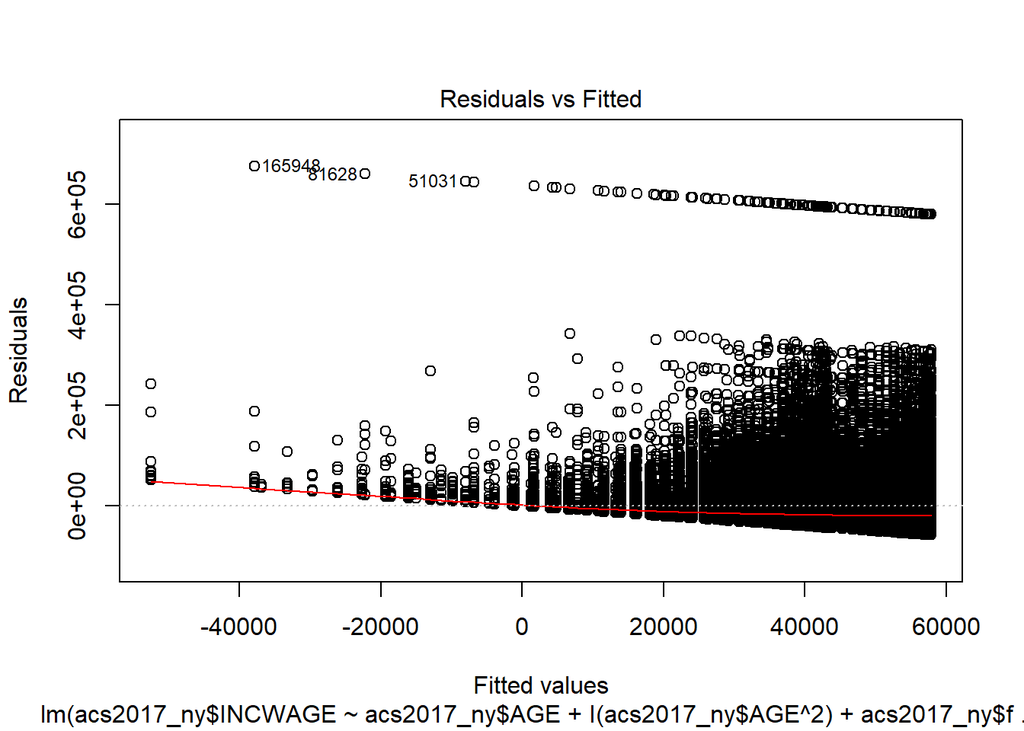

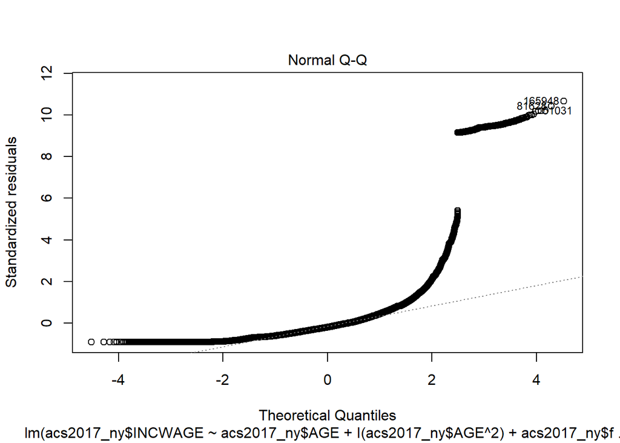

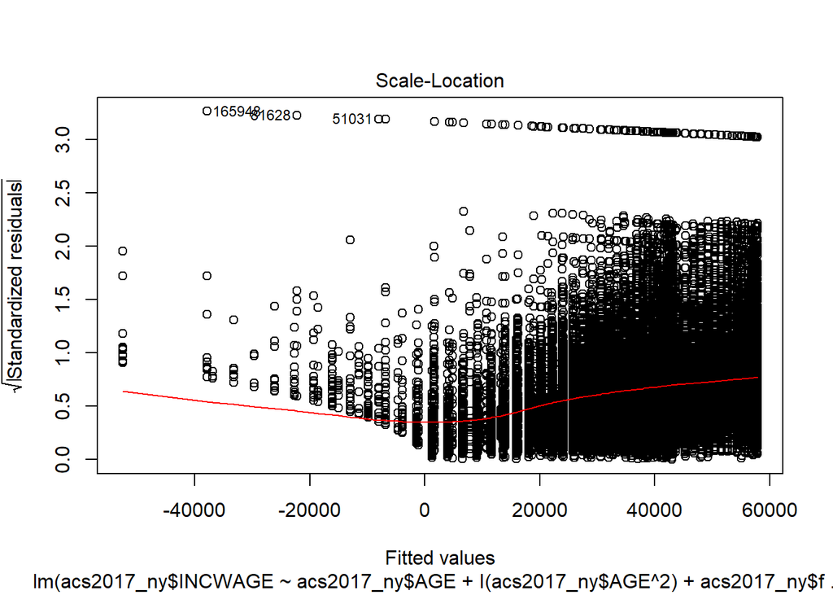

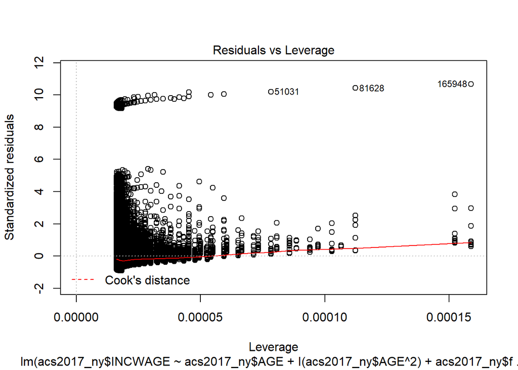

```r
plot(LinearGender)
```

```r
length(acs2017_ny$AGE)
```

```
## [1] 196585
```

```r
length(LinearGender$fitted.values)
```

```
## [1] 163158
```

```r
length(acs2017_ny$female)
```

```
## [1] 196585
```

What are the other variables you are using in your regression? Do they have the expected signs and patterns of significance? Explain if there is a plausible causal link from X variables to Y and not the reverse. Explain your results, giving details about the estimation, some predicted values, and providing any relevant graphics. Impress. - Age and gender can’t have a reverse relationship with wage. Y effecting X in this case since wage can’t effect your age and gender.